# Markov Chains for Sequence Clustering

Lauren Flemmer

### Sepsis

Sepsis is a condition that occurs when the body’s response to an infection begins to damage its own tissues. Sepsis is extremely life threatening, with around a 40% mortality rate due to its ability to damage organs and cause them to fail. As sepsis becomes worse, blood flow to the brain, heart, kidneys, and other organs decrease. Treatment for sepsis includes antibiotics and to maintain blood flow to organs.

### The Data

The data used for this analysis is a real patient event log obtained from **BupaR’s eventdataR package**, and describes **management of sepsis patients**, from their admission to their discharge. _______________________________________________________________________________________________________________________________

The goal of this analysis is to develop a way to cluster sepsis patient event sequences using markov chains.

### Markov Chains

A markov chain is a **probabilistic model showing a sequence of events**, where the **probability of an event occurring depends only on the event that occurred before it**. Therefore, it is a good way to model the sepsis data, since it consists of many different events occurring over time for each patient.

#### Splitting up the data

In order to cluster the event sequences, we need pre-defined clusters to assign the sequences to. Therefore, the patients (cases) will be split into test and training sets: the training set will be used to create the initial clusters, and the test set will consist of the sequences of events we are trying to cluster.

```r
#split into test and train sets

# Randomly assign train/test groups to all values of case_id (split by groups)
groups <-
  sepsisData %>%
  select(case_id) %>%
  distinct(case_id) %>%
  rowwise() %>%
  mutate(group = sample(
    c("train", "test"),
    1, replace = TRUE, prob = c(0.5, 0.5)))


# Join group assignments to data
sepsisData <- sepsisData %>% left_join(groups)

#training set
trainingData <- sepsisData %>% filter(group == "train")

#test set
testData <- sepsisData %>% filter(group == "test")
```

Since we are working with sequences of events, the data will be transformed so the events for each patient are in list format, rather than each event being a single row/observation.

```r
#format test and train data "activity" variable to be list of events for each case_id
trainingDataGrouped <- trainingData %>% arrange(case_id, timestamp) %>% select(case_id, activity) %>% group_by(case_id) %>% mutate(sequence = paste(activity, collapse = ","))
testDataGrouped <- testData %>% arrange(case_id, timestamp) %>% select(case_id,                                                                                                                                                                                                                                                            activity) %>% group_by(case_id) %>% mutate(sequence = paste(activity, collapse = ","))

trainingDataGrouped <- trainingDataGrouped %>% select(case_id, sequence) %>% unique()
trainingDataGrouped$sequence <- as.vector(trainingDataGrouped$sequence)

testDataGrouped <- testDataGrouped %>% select(case_id, sequence) %>% unique()
testDataGrouped$sequence <- as.vector(testDataGrouped$sequence)

trainingDataGrouped$sequence <- strsplit(trainingDataGrouped$sequence, split=",")
testDataGrouped$sequence <- strsplit(testDataGrouped$sequence, split=",")

head(testDataGrouped, 5)
```

```
## # A tibble: 5 x 2
## # Groups:   case_id [5]
##   case_id sequence
##   <chr>   <list>
## 1 A       <chr [22]>
## 2 AA      <chr [8]>
## 3 AB      <chr [8]>
## 4 ABA     <chr [17]>
## 5 ACA     <chr [8]>
```

This is the new format for the data set- now each row, instead of representing a specific event, represents a patient (case_id). The ‘activity’ column is now the ‘sequence’ column, which is a list of each patient’s events in the order in which they occurred.

### Cluster creation

The event **“Release A” represents the patient’s initial release from the hospital**. However, the data also includes events “Release B”, “Release C”, “Release D”, and “Release E”. **If a patient has any of Release B-E in their sequence, they had to return to the hospital for additional treatment, then were released again**. Therefore, I am splitting the patients and their event sequences into the following 2 clusters:

- **Cluster 1: Patient was readmitted**
- **Cluster 2: Patient was not readmitted**

By looking at each patient’s sequence of events, we know that a patient was not readmitted to the hospital if their last event is “Release A”. If the last event of their sequence is not “Release A”, then they had to be readmitted for additional treatments.

```r
#get last event of case
for (i in 1:length(trainingDataGrouped$sequence)) {
  trainingDataGrouped$lastEvent[i] <- trainingDataGrouped$sequence[[i]][length(trainingDataGrouped$sequence[[i]])]
}
for (i in 1:length(testDataGrouped$sequence)) {
  testDataGrouped$lastEvent[i] <- testDataGrouped$sequence[[i]][length(testDataGrouped$sequence[[i]])]
}


#cases that end with "Release A" (no hospital readmission)
noReadmissionTrain <- trainingDataGrouped %>% filter(lastEvent == "Release A")

#cases that do not end with "Release A" (hospital readmission)
readmissionTrain <- trainingDataGrouped %>% filter(lastEvent != "Release A")

testDataGrouped$label <- ifelse(testDataGrouped$lastEvent == "Release A", "Patient Not Readmittted", "Patient Readmitted")
testDataLabel <- testDataGrouped %>% select(case_id, label)
```

For each patient, their “Last event” was obtained, so we can figure out which patients had to be readmitted. Below is a table showing the different “Last events” and their frequencies.

```r
#table of final events in sequences
table(trainingDataGrouped$lastEvent)
```

```
##
##     Admission NC              CRP ER Sepsis Triage        ER Triage
##                8               22               25                1
##   IV Antibiotics        IV Liquid       LacticAcid       Leucocytes
##               47                8               12               21
##        Release A        Release B        Release C        Release D
##              189               33                8                6
##        Release E        Return ER
##                3              140
```

Now that the patients are separated into the 2 groups, those groups will be used to make the markov chains. However, to make the markov chains, the data needs to be in the original format, where each row represented an individual patient event. Right now, it is still in the ‘sequence format’, where it is grouped by patient, and the patient’s events are represented as a single data entry. So, to get the data back to the original format while keeping the ‘lastEvent’, we will join the original dataset with our new (grouped by patient) dataset.

```r
#rejoin with timestamp variable
noReadmissionTrain <- inner_join(sepsisData, noReadmissionTrain, by = "case_id") %>% select(case_id, activity, timestamp)
readmissionTrain <- inner_join(sepsisData, readmissionTrain, by = "case_id") %>% select(case_id, activity, timestamp)

testDataGrouped <- inner_join(sepsisData, testDataGrouped, by = "case_id") %>% select(case_id, activity, timestamp)

#order by date
noReadmissionTrain <- noReadmissionTrain[order(as.Date(noReadmissionTrain$timestamp, format="%d-%m-%Y:%H.%M")),]
readmissionTrain <- readmissionTrain[order(as.Date(readmissionTrain$timestamp, format="%d-%m-%Y:%H.%M")),]

testDataGrouped <- testDataGrouped[order(as.Date(testDataGrouped$timestamp, format="%d-%m-%Y:%H.%M")),]
head(testDataGrouped, 5)
```

```
##    case_id         activity           timestamp
## 48       I  ER Registration 2013-11-09 09:21:03
## 49       I        ER Triage 2013-11-09 09:34:28
## 50       I ER Sepsis Triage 2013-11-09 09:34:41
## 51       I   IV Antibiotics 2013-11-09 09:34:56
## 52       I       Leucocytes 2013-11-09 09:42:00
```

#### Cluster 1: Hospital Readmission

[interactive chart not shown]

#### Cluster 2: No Hospital Readmission

[interactive chart not shown]

### Transition Probability Matrices

Now that the data is separated into the 2 groups that represent our ‘clusters’, the 2 markov chains will be created using the training data. Note that these markov chains are not created with respect to each patient, rather, all events (from all patients) are used as a single ‘list’ of **chronological** events. For both the **Patient Readmitted** and the **Patient Not Readmitted** markov chains, a transition probability matrix will be obtained, which **stores the probabilities of transitioning from one event to another**.

#### Hospital Readmission Probability Transition Matrix

```
##              [,1]       [,2]        [,3]       [,4]        [,5]        [,6]
##  [1,] 0.000000000 0.05405405 0.243243243 0.08108108 0.000000000 0.000000000
##  [2,] 0.006666667 0.10000000 0.190000000 0.18000000 0.003333333 0.000000000
##  [3,] 0.003232759 0.05064655 0.056034483 0.08620690 0.011853448 0.007543103
##  [4,] 0.002994012 0.00000000 0.005988024 0.00000000 0.011976048 0.940119760
##  [5,] 0.000000000 0.02102102 0.207207207 0.02402402 0.000000000 0.006006006
##  [6,] 0.000000000 0.00000000 0.050595238 0.01488095 0.833333333 0.000000000
##  [7,] 0.053061224 0.50612245 0.077551020 0.07755102 0.000000000 0.008163265
##  [8,] 0.000000000 0.06278027 0.062780269 0.04484305 0.008968610 0.008968610
##  [9,] 0.010638298 0.05531915 0.259574468 0.02978723 0.034042553 0.008510638
## [10,] 0.013184584 0.04361055 0.498985801 0.06997972 0.016227181 0.004056795
## [11,] 0.000000000 0.01515152 0.250000000 0.21969697 0.007575758 0.000000000
## [12,] 0.000000000 0.02941176 0.117647059 0.35294118 0.000000000 0.000000000
## [13,] 0.000000000 0.00000000 0.090909091 0.54545455 0.000000000 0.090909091
## [14,] 0.000000000 0.00000000 0.166666667 0.08333333 0.000000000 0.000000000
```

[output cut: 36 more lines]

#### No Hospital Readmission Probability Transition Matrix

```
##              [,1]       [,2]       [,3]        [,4]        [,5]        [,6]
##  [1,] 0.000000000 0.04166667 0.37500000 0.083333333 0.041666667 0.000000000
##  [2,] 0.014705882 0.08088235 0.27941176 0.154411765 0.011029412 0.000000000
##  [3,] 0.002958580 0.06952663 0.07840237 0.069526627 0.005917160 0.001479290
##  [4,] 0.000000000 0.00000000 0.01587302 0.000000000 0.015873016 0.915343915
##  [5,] 0.000000000 0.03703704 0.21164021 0.005291005 0.000000000 0.010582011
##  [6,] 0.000000000 0.00000000 0.03174603 0.000000000 0.888888889 0.000000000
##  [7,] 0.085365854 0.69512195 0.04878049 0.000000000 0.000000000 0.006097561
##  [8,] 0.006802721 0.05442177 0.06122449 0.013605442 0.006802721 0.034013605
##  [9,] 0.000000000 0.07420495 0.25795053 0.035335689 0.017667845 0.014134276
## [10,] 0.003012048 0.06325301 0.53463855 0.063253012 0.004518072 0.004518072
## [11,] 0.005319149 0.05319149 0.23404255 0.223404255 0.005319149 0.000000000
## [12,] 0.000000000 0.00000000 0.00000000 0.000000000 0.000000000 0.000000000
## [13,] 0.000000000 0.00000000 0.00000000 0.000000000 0.000000000 0.000000000
## [14,] 0.000000000 0.00000000 0.00000000 0.000000000 0.000000000 0.000000000
```

[output cut: 36 more lines]

Note that the **rows** of the matrix represent the **antecedent event**, and the **columns** represent the **consequent event**.

### Clustering patient event sequences

To cluster the sequences, the probability of each **test sequence** occurring in both the “Hospital Readmission” and “No Hospital Readmission” clusters will be **calculated using each cluster’s transition probability matrix** using the following formulas.

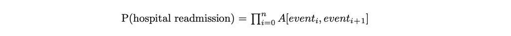

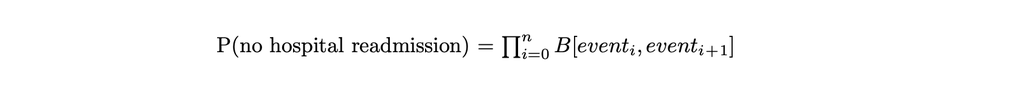

```r
#create probability df
clusterProbabilities <- data.frame(readmissionProb = double(), noReadmissionProb = double())

#iterate over rows of dataframe
for (row in 1:nrow(testDataGrouped)) {

  current_prob_readmission <- 1
  current_prob_noreadmission <- 1

  #iterate through sequence of events (up until second-to-last event in sequence)
  for (item in 1:(length(testDataGrouped$sequence[[ row]])-1)) {
    transitionProb_readmission <- 1
    transitionProb_noReadmission <- 1

    #cluster 1 (readmission)
    state1index_readmission <- which(testDataGrouped$sequence[[ row]][item] == readmissionLabels)
    state2index_readmission <- which(testDataGrouped$sequence[[ row]][[item+1]] == readmissionLabels)
    transitionProb_readmission <- readmissionTransitionProb[state1index_readmission, state2index_readmission]

    current_prob_readmission <- current_prob_readmission * transitionProb_readmission

    #cluster 2 (no readmission)
    state1index_noReadmission <- which(testDataGrouped$sequence[[ row]][item] == readmissionLabels)
    state2index_noReadmission <- which(testDataGrouped$sequence[[ row]][item+1] == readmissionLabels)
    transitionProb_noReadmission <- noReadmissionTransitionProb[state1index_noReadmission, state2index_noReadmission]

    current_prob_noreadmission <- current_prob_noreadmission * transitionProb_noReadmission


  }
  #add probabilities for that patient to the clusterProbability df
  bothProb_vec <- c(testDataGrouped$case_id[row], current_prob_readmission, current_prob_noreadmission)

  clusterProbabilities <- rbind(clusterProbabilities, bothProb_vec)
}

names(clusterProbabilities)[1] <- "case_id"
names(clusterProbabilities)[2] <- "readmissionProb"
names(clusterProbabilities)[3] <- "noReadmissionProb"
```

Now that the probability of the sequence belonging to each cluster is obtained, the **cluster the sequence will be assigned to** is the **cluster with the larger probability**.

```r
#assign cluster as group w/ highest probability
case_id_temp <- clusterProbabilities$case_id
clusterProb_temp <- clusterProbabilities %>% select(readmissionProb, noReadmissionProb)
clusterProb_temp$cluster <- colnames(clusterProb_temp)[max.col(clusterProb_temp,ties.method="first")]

clusterProbabilities <- cbind(case_id_temp, clusterProb_temp)
names(clusterProbabilities)[1] <- "case_id"

clusterProbabilities$cluster <- ifelse(clusterProbabilities$cluster == "readmissionProb", "Patient Readmitted", "Patient Not Readmitted")
head(clusterProbabilities, 10)
```

```
##    case_id      readmissionProb    noReadmissionProb                cluster
## 1        A 1.28840078213384e-15 1.57850523767252e-14 Patient Not Readmitted
## 2       AA 0.000143099516696639 0.000141217300225169     Patient Readmitted
## 3       AB 0.000261677557264076 0.000348399858366609 Patient Not Readmitted
## 4      ABA 4.56896940268549e-11 3.08327647411548e-10 Patient Not Readmitted
## 5      ACA 0.000261677557264076 0.000348399858366609 Patient Not Readmitted
## 6       AE 8.83885826860603e-13                    0     Patient Readmitted
## 7      AEA 9.46228453817645e-05 0.000223218780691782 Patient Not Readmitted
## 8       AF  7.1655540062552e-15                    0     Patient Readmitted
## 9      AFA 1.37940705331211e-10                    0     Patient Readmitted
## 10     AGA  4.3742919709468e-09 2.84787705069705e-08 Patient Not Readmitted
```

Above, you can see that for each patient (case_id) sequence, a probability they were readmitted, and a probability they weren’t readmitted was obtained, and the larger of the two determines the cluster the patient belongs to: **“Patient Readmitted”**, **“Patient Not Readmitted”** _______________________________________________________________________________________________________________________________

#### Clustering accuracy

```r
#check accuracy of clusters

joined_results <- inner_join(testDataLabel, clusterProbabilities, by = "case_id")

#transform to binary variable
joined_results$cluster <- ifelse(joined_results$cluster == "Patient Readmitted", 1, 0)
joined_results$label <- ifelse(joined_results$label == "Patient Readmitted", 1, 0)


mean(joined_results$cluster == joined_results$label)
```

```
## [1] 0.8060837
```

#### Transition Matrix Validation

To validate the markov chain transition matrices, the obtained markov chain probability distributions (transition matrices) will be compared to their stationary distributions. The **stationary distribution** of a markov chain is the **long-run** probability distribution of a markov chain, and “describes the distribution of X after a sufficiently long time that the distribution of X does not change any longer”. [7] The stationary distribution can thus be treated as the **population probability distribution** of the markov chain. The stationary distribution of a markov chain can be computed by raising it’s transition matrix to a high power. _______________________________________________________________________________________________________________________________

So, for both the **Hospital Readmission** and **No Hospital Readmission** markov chains, their stationary distributions will be calculated and compared to the transition matrices we obtained from our analysis. They will be compared using **Kullback-Leibler Divergence**, which is used to measure the **dissimilarity between two probability distributions**.

##### Hospital Readmission

```r
#Finding equilibrium distribution for markov chain
readmission_stationary_dist <- (readmissionTransitionProb^100)

KL.divergence(readmissionTransitionProb, readmission_stationary_dist)
```

```
##  [1] 10.5497331  7.7211568  5.8709521  4.6633957  3.7232630  3.0817110
##  [7]  1.7279420  0.9325170 -0.3529959 -1.8513504
```

##### No Hospital Readmission

```r
#Finding equilibrium distribution for markov chain
noReadmission_stationary_dist <- (noReadmissionTransitionProb^100)

KL.divergence(noReadmissionTransitionProb, noReadmission_stationary_dist)
```

```
##  [1]       NaN       NaN       NaN       NaN      -Inf -658.0219 -633.9667
##  [8] -613.9997 -487.2537 -460.6592
```

### References

1. https://www.bupar.net/eventdataR.html
2. https://www.bupar.net/
3. https://www.researchgate.net/publication/265160829_Applying_Hidden_Markov_Models_to_Process_Mining
4. https://brilliant.org/wiki/markov-chains/#:~:text=A%20Markov%20chain%20is%20a,possible%20future%20states%20are%20fixed.
5. https://www.stat.auckland.ac.nz/~fewster/325/notes/ch9.pdf
6. https://www.statlect.com/fundamentals-of-probability/Kullback-Leibler-divergence
7. https://stephens999.github.io/fiveMinuteStats/markov_chains_discrete_stationary_dist.html#:~:text=The%20stationary%20distribution%20of%20a%20Markov%20chain%20describes%20the%20distribution,a%20Markov%20chain%20can%20visit.
8. https://www.math.umd.edu/~immortal/MATH401/ch_markov_chains.pdf